# Projet_PRO1036

Audrey Bergeron

2024-12-02

### Importation des données et chargement des packages

Tout d’abord, nous allons charger les packages nécessaires (déjà installés) pour réaliser l’analyse. Ainsi, nous allons charger “tidyverse”, “readr” et “tidymodels”.

```r
# Chargement des packages
library(tidyverse)
library(readr)
library(tidymodels)
```

La deuxième étape est d’importer les données cumulatives des urgences au Québec. Ces données sont dans un fichier csv, d’où la nécessité de charger le package “readr”. Ainsi, nous allons importer ces données avec la fonction read_delim(), puisque le délimiteur est un point-virgule.

```r
# Importation des données cumulatives des urgences
urgences <- read_delim("Donnees_cumulatives_Urgence.csv")
```

Finalement, la dernière étape est d’importer les données concernant la population selon les régions sociosanitaires. Ces données, datant de 2023, sont fournies par l’Institut de la statistique du Québec (https://statistique.quebec.ca/fr/document/le-quebec-chiffres-en-main). Finalement, ces données ont été ajoutées dans un fichier csv.

```r
# Importation des données de la population des régions sociosanitaires
population_2023 <- read_delim("Population_region_sociosanitaire.csv")
```

### Introduction

Depuis plusieurs années, les urgences font malheureusement les manchettes des journaux pour les délais d’attente interminables. Dans certains cas, les longs délais de prise en charge ont conduit à des résultats désastreux, tels que la mort de patients aux urgences. La population québécoise demande des explications concernant cette situation en plus d’exiger des réformes afin d’améliorer le système des urgences au Québec. Il est inconcevable d’attendre des heures pour voir un médecin à l’urgence : le terme est clair, des soins médicaux sont nécessaires dans l’immédiat. Ceci mène à plusieurs questionnements et problématiques. En effet, la présente analyse essaiera de présenter divers liens afin d’expliquer la situation des urgences au Québec. Plus précisément, nous allons regarder les relations pour l’année courante, en plus de regarder le cumulatif des 4 dernières années. Ainsi, les questions de recherches qui seront répondues sont :

1 - Quelle est la durée moyenne du séjour, selon les régions sociosanitaires, pour les urgences au Québec pour l’année courante? Pour les 4 dernières années? 2 - Quel est le nombre moyen de patients en attente de prise en charge par région sociosanitaire pour l’année courante? 3 - Existe-t-il une relation linéaire entre la durée du séjour et le délai de prise en charge pour les patients (ambulatoires et sur civière)? 4 - Quelle est la relation entre le nombre de patients ambulatoires en attente de prise en charge et le nombre de patients ambulatoires pour une région sociosanitaire pour l’année courante? Pour les 4 dernières années? 5 - Quelle est la corrélation entre la densité de la population et l’achalandage à l’urgence selon les régions sociosanitaires pour l’année courante? 6 - Quelle est la relation entre l’achalandage, la densité de la population et le nombre de patients pris en charge dans les urgences selon les régions sociosanitaires du Québec pour l’année courante?

### Données

Comme déjà mentionnées dans la section “importation des données et chargement des packages”, les données cumulatives des urgences du Québec proviennent de Données Québec (https://www.donneesquebec.ca/recherche/dataset/fichier-cumulatif-des-donnees-des-urgences), plus précisément de la Banque de données communes des urgences (BDCU). Ce fichier présente les données cumulatives de certaines informations des urgences du 1er avril à la fin de la dernière période validée de l’année financière courante, ainsi que les données cumulatives des 4 dernières années financières. Ce fichier est mis à jour à chaque période financière. De plus, les données sont présentées pour chaque région sociosanitaire du Québec que voici :

1. Bas-Saint-Laurent, (2) Saguenay-Lac-Saint-Jean, (3) Capitale-Nationale, (4) Mauricie et Centre-du-Québec, (5) Estrie, (6) Montréal, (7) Outaouais, (8) Abitibi-Témiscamingue, (9) Côte-Nord, (10) Gaspésie-Îles-de-la-Madeleine, (11) Chaudière-Appalaches, (12) Laval, (13) Lanaudière, (14) Laurentides, (15) Montérégie

Ce jeu de données des urgences comporte 27 variables et 795 observations. Cependant, certaines variables ne seront pas prises en compte, telles que a) cumul_period b) nom_établissement c) nom_installation d) no_permis_installation e) nb_usagers_75ans_et_plus_amb f) nb_usagers_75ans_et_plus_civ

Pour poursuivre, voici les explications concernant les variables utilisées et intéressantes pour la présente analyse. 1) annee : année dans laquelle a débuté l’épisode de soins. 2) rss : numéro de région sociosanitaire dans laquelle se situe l’installation. 3) region : région sociosanitaire dans laquelle se situe l’installation. 4) nb_visites_total : nombre total de visites à l’urgence, incluant les usagers ambulatoires et sur civière. 5) nb_usagers_75ans_et_plus_total : nombre total de visites à l’urgence pour les patients âgés de 75 ans et plus. 6) nb_usagers_sante_mentale_total : nombre total de visites à l’urgence pour les usagers ayant une problématique en santé mentale. 7) dms_total : durée moyenne de séjour pour l’ensemble des usagers, où cette variable représente la durée entre l’arrivée et le départ de l’usager de l’urgence. Les données sont en format de nombre décimal. 8) nb_usagers_pec_total : nombre d’usagers total pris en charge par un médecin. 9) delai_pec_total : délai de prise en charge pour les usagers (ambulatoires et sur civière) ayant été pris en charge par un médecin 10) nb_visites_ambulatoire : nombre de visites à l’urgence pour des usagers ambulatoires (n’exigent pas d’être sur une civière). 11) nb_usagers_sante_mentale_amb : nombre de visites ambulatoires à l’urgence pour les usagers ayant une problématique en santé mentale. 12) dms_ambulatoire : durée moyenne de séjour ambulatoire, où cette variable représente la durée entre l’arrivée et le départ de l’usager de l’urgence pour les patients en salle d’attente. Les données sont en nombres décimaux. 13) nb_usagers_pec_ambulatoire : nombre d’usagers ambulatoires pris en charge par un médecin. 14) delai_pec_ambulatoire : délai de prise en charge pour des usagers ambulatoires. 15) nb_visites_sur_civiere : nombre de visites à l’urgence pour des usagers sur civière. 16) nb_usagers_sur_civiere_plus_24h : nombre d’usagers sur civière dont la durée de séjour à l’urgence a été égale ou plus grande que 24 heures. 17) nb_usagers sur civiere_plus_48h : nombre d’usagers sur civière dont la durée du séjour à l’urgence a été égale ou plus grande que 48 heures. 18) dms_sur_civiere : durée moyenne de séjour sur civière, où cette variable correspond entre l’arrivée et le départ de l’usager. 19) nb_usagers_pec_sur_civiere : nombre d’usagers sur civière pris en charge par un médecin. 20) delai_pec_sur_civiere : délai de prise en charge pour des usagers sur civière. 21) nb_usagers_sante_mentale_civ : nombre de visites sur civière à l’urgence pour les usagers ayant une problématique en santé mentale.

Ensuite, les données de la population selon les régions sociosanitaires sont également importées depuis l’Institut de la statistique du Québec (https://statistique.quebec.ca/fr/document/le-quebec-chiffres-en-main). Ici, les données ont été entrées dans un fichier Excel, puis converties en fichier csv. Ainsi, ce fichier permet d’obtenir la population, en 2023, pour les 15 régions sociosanitaires. Finalement, il est important de mentionner que le nombre d’habitants pour les régions de la Mauricie et du Centre-du-Québec a été additionné puisque ces deux régions, dans les données des urgences, sont considérées comme une seule région.

### Analyse des données

Tout d’abord, commençons par regarder les deux jeux de données afin de vérifier que les données sont tidy.

```r
# Visualisation de "urgences"
glimpse(urgences)
```

```
## Rows: 795
## Columns: 27
## $ annee                           <chr> "2020-2021", "2021-2022", "2022-2023",…
## $ cumul_periode                   <dbl> 8, 8, 8, 8, 8, 8, 8, 8, 8, 8, 8, 8, 8,…
## $ rss                             <chr> "99", "99", "99", "99", "99", "08", "0…
## $ region                          <chr> "Total provincial", "Total provincial"…
## $ nom_etablissement               <chr> "Total provincial", "Total provincial"…
## $ nom_installation                <chr> "Total provincial", "Total provincial"…
## $ no_permis_installation          <dbl> NA, NA, NA, NA, NA, NA, NA, NA, NA, NA…
## $ nb_visites_total                <dbl> 1678250, 2087097, 2218598, 2165092, 23…
## $ nb_usagers_75ans_et_plus_total  <dbl> 259412, 306326, 327901, 349551, 386534…
## $ nb_usagers_sante_mentale_total  <dbl> 111405, 127300, 126447, 126876, 137816…
## $ dms_total                       <dbl> 7.855917, 8.359522, 8.948683, 8.836999…
## $ nb_usagers_pec_total            <dbl> 1440338, 1697904, 1757732, 1749569, 19…
## $ delai_pec_total                 <dbl> 1.8604981, 2.5332071, 2.8342550, 2.806…
## $ nb_visites_ambulatoire          <dbl> 1082564, 1416866, 1533043, 1458532, 16…
## $ nb_usagers_75ans_et_plus_amb    <dbl> 87321, 112623, 122398, 134349, 148639,…
## $ nb_usagers_sante_mentale_amb    <dbl> 43941, 53344, 51849, 50402, 54276, 245…
## $ dms_ambulatoire                 <dbl> 3.749945, 4.590857, 4.936865, 4.901941…
## $ nb_usagers_pec_ambulatoire      <dbl> 849322, 1033743, 1079597, 1050606, 113…
## $ delai_pec_ambulatoire           <dbl> 2.199398, 3.013796, 3.374375, 3.320795…
## $ nb_visites_sur_civiere          <dbl> 595686, 670231, 685555, 706560, 769519…
## $ nb_usagers_sur_civiere_plus_24h <dbl> 114794, 142090, 163264, 158424, 168404…
## $ nb_usagers_sur_civiere_plus_48h <dbl> 26498, 35970, 50083, 41321, 40155, 110…
## $ dms_sur_civiere                 <dbl> 15.317866, 16.326468, 17.919939, 16.96…
## $ nb_usagers_pec_sur_civiere      <dbl> 591016, 664161, 678135, 698963, 760622…
## $ delai_pec_sur_civiere           <dbl> 1.3734807, 1.7851872, 1.9743786, 2.032…
## $ nb_usagers_75ans_et_plus_civ    <dbl> 172091, 193703, 205503, 215202, 237895…
## $ nb_usagers_sante_mentale_civ    <dbl> 67464, 73956, 74598, 76474, 83540, 846…
```

```r
# Jeu de données my_urgences
my_urgences <- urgences %>%
  select(-c(cumul_periode, nom_etablissement, nom_installation, no_permis_installation, nb_usagers_75ans_et_plus_amb, nb_usagers_75ans_et_plus_civ)) %>%
  glimpse()
```

```
## Rows: 795
## Columns: 21
## $ annee                           <chr> "2020-2021", "2021-2022", "2022-2023",…
## $ rss                             <chr> "99", "99", "99", "99", "99", "08", "0…
## $ region                          <chr> "Total provincial", "Total provincial"…
## $ nb_visites_total                <dbl> 1678250, 2087097, 2218598, 2165092, 23…
## $ nb_usagers_75ans_et_plus_total  <dbl> 259412, 306326, 327901, 349551, 386534…
## $ nb_usagers_sante_mentale_total  <dbl> 111405, 127300, 126447, 126876, 137816…
## $ dms_total                       <dbl> 7.855917, 8.359522, 8.948683, 8.836999…
## $ nb_usagers_pec_total            <dbl> 1440338, 1697904, 1757732, 1749569, 19…
## $ delai_pec_total                 <dbl> 1.8604981, 2.5332071, 2.8342550, 2.806…
## $ nb_visites_ambulatoire          <dbl> 1082564, 1416866, 1533043, 1458532, 16…
## $ nb_usagers_sante_mentale_amb    <dbl> 43941, 53344, 51849, 50402, 54276, 245…
## $ dms_ambulatoire                 <dbl> 3.749945, 4.590857, 4.936865, 4.901941…
## $ nb_usagers_pec_ambulatoire      <dbl> 849322, 1033743, 1079597, 1050606, 113…
## $ delai_pec_ambulatoire           <dbl> 2.199398, 3.013796, 3.374375, 3.320795…
## $ nb_visites_sur_civiere          <dbl> 595686, 670231, 685555, 706560, 769519…
## $ nb_usagers_sur_civiere_plus_24h <dbl> 114794, 142090, 163264, 158424, 168404…
## $ nb_usagers_sur_civiere_plus_48h <dbl> 26498, 35970, 50083, 41321, 40155, 110…
## $ dms_sur_civiere                 <dbl> 15.317866, 16.326468, 17.919939, 16.96…
## $ nb_usagers_pec_sur_civiere      <dbl> 591016, 664161, 678135, 698963, 760622…
## $ delai_pec_sur_civiere           <dbl> 1.3734807, 1.7851872, 1.9743786, 2.032…
## $ nb_usagers_sante_mentale_civ    <dbl> 67464, 73956, 74598, 76474, 83540, 846…
```

- Note importante : il est possible de remarquer que les régions sociosanitaires ont plusieurs urgences. Cependant, pour la présente analyse, je ne considérai seulement que la moyenne des urgences pour une région c’est-à-dire que je ne regarderai pas les données pour toutes les urgences d’une même région. Ici, je m’intéresse principalement aux régions sociosanitaires.

Ensuite, nous allons regarder le jeu de données “population_2023” afin de vérifier que les données sont tidy.

```r
# Visualisation de population_2023
glimpse(population_2023)
```

```
## Rows: 15
## Columns: 3
## $ region_sociosanitaire <chr> "Bas-Saint-Laurent ", "Saguenay-Lac-Saint-Jean",…
## $ `population `         <dbl> 202955, 283234, 795917, 543222, 516919, 2124865,…
## $ rss                   <chr> "01", "02", "03", "04", "05", "06", "07", "08", …
```

# 1 - Quelle est la durée moyenne du séjour, selon les régions sociosanitaires, pour les urgences au Québec pour l’année courante? Pour les 4 dernières années?

Nous allons commencer par regarder la durée moyenne de séjour dans les urgences, selon les régions sociosanitaires, pour l’année courante (2024-2025). Ainsi, nous allons être en mesure de voir la durée du séjour des usagers (ambulatoires et sur civière) entre leur arrivée et leur départ. Finalement, les résultats obtenus sont la moyenne de la durée du séjour des différents établissements dans les régions sociosanitaires.

```r
# Durée moyenne du séjour des usagers en 2024-2025
my_urgences %>%
  filter(annee == "2024-2025") %>%
  group_by(region) %>%
  count(dms_total) %>%
  summarise(mean_dms = mean(dms_total)) %>%
  arrange(desc(mean_dms))
```

```
## # A tibble: 16 × 2
##    region                        mean_dms
##    <chr>                            <dbl>
##  1 Montréal                         11.6
##  2 Montérégie                       11.3
##  3 Laval                            10.7
##  4 Laurentides                      10.5
##  5 Lanaudière                       10.0
##  6 Total provincial                  8.84
##  7 Estrie                            7.96
##  8 Outaouais                         7.80
##  9 Mauricie et Centre-du-Québec      6.48
## 10 Capitale-Nationale                6.44
## 11 Saguenay-Lac-Saint-Jean           6.13
## 12 Chaudière-Appalaches              5.85
## 13 Côte-Nord                         5.67
## 14 Abitibi-Témiscamingue             5.64
## 15 Gaspésie-Îles-de-la-Madeleine     4.70
## 16 Bas-Saint-Laurent                 4.40
```

Ensuite, regardons la durée moyenne de séjour dans les urgences, selon les régions sociosanitaires, pour les 4 dernières années. Ainsi, nous allons être en mesure de voir la durée du séjour des usagers (ambulatoires et sur civière) entre leur arrivée et leur départ. Finalement, les résultats obtenus sont la moyenne de la durée du séjour des différents établissements dans les régions sociosanitaires.

```r
# Durée moyenne du séjour des usagers pour les 4 dernières années
my_urgences %>%
  filter(annee == c("2020-2021", "2021-2022", "2022-2023", "2023-2024")) %>%
  group_by(region, annee) %>%
  count(dms_total) %>%
  summarise(mean_dms = mean(dms_total))
```

```
## # A tibble: 62 × 3
## # Groups:   region [16]
##    region                annee     mean_dms
##    <chr>                 <chr>        <dbl>
##  1 Abitibi-Témiscamingue 2020-2021     4.36
##  2 Abitibi-Témiscamingue 2021-2022     5.10
##  3 Abitibi-Témiscamingue 2022-2023     5.00
##  4 Abitibi-Témiscamingue 2023-2024     4.51
##  5 Bas-Saint-Laurent     2020-2021     4.23
##  6 Bas-Saint-Laurent     2021-2022     3.02
##  7 Bas-Saint-Laurent     2022-2023     4.94
##  8 Bas-Saint-Laurent     2023-2024     3.46
##  9 Capitale-Nationale    2020-2021     5.95
## 10 Capitale-Nationale    2021-2022     6.59
## # ℹ 52 more rows
```

En ce qui concerne la durée moyenne pour les 4 dernières années, nous allons simplement regarder la tendance générale de la durée du séjour. Ainsi, de manière générale, les régions ont des durées moyennes de séjour, pour l’année 2024-2025, qui tendent vers les moyennes des 4 dernières années. Cependant, certaines régions se démarquent : Laval, Mauricie, Saguenay-Lac-Saint-Jean et Abitibi-Témiscamingue ont tous eu des durées moyennes supérieures à celles des 4 dernières années. Ceci peut être expliqué par plusieurs facteurs, tels qu’une migration vers ces régions. Finalement, une dernière observation est l’intervalle des durées moyennes des 4 dernières années. En effet, il y a 4 régions qui ont des intervalles non négligeables. La Mauricie a un écart de 3.09 heures, Montréal est de 4.37 heures, Montérégie est de 3.12 heures et Outaouais est de 4.04 heures. Une fois de plus, une migration vers ces régions peut être un facteur expliquant cet écart.

Maintenant, afin de bien distinguer les durées moyennes de séjours pour les patients ambulatoires (dans la salle d’attente) et les patients sur civière, nous allons regarder la durée moyenne pour l’année courante (2024-2025). Ceci permettra de poser une hypothèse quant au séjour selon le type de patient.

```r
# Durée moyenne du séjour pour les patients ambulatoires et sur civière
my_urgences %>%
  filter(annee == "2024-2025") %>%
  group_by(region) %>%
  count(dms_ambulatoire, dms_sur_civiere) %>%
  summarise(mean_ambulatoire = mean(dms_ambulatoire),
            mean_civiere = mean(dms_sur_civiere)) %>%
  arrange(desc(mean_ambulatoire))
```

```
## # A tibble: 16 × 3
##    region                        mean_ambulatoire mean_civiere
##    <chr>                                    <dbl>        <dbl>
##  1 Laval                                     6.53        17.6
##  2 Montérégie                                6.11        20.4
##  3 Laurentides                               6.06        19.8
##  4 Lanaudière                                5.78        18.3
##  5 Estrie                                    5.72        12.6
##  6 Montréal                                  5.58        21.0
##  7 Total provincial                          5.08        16.7
##  8 Outaouais                                 5.08        15.8
##  9 Mauricie et Centre-du-Québec              4.65        10.2
## 10 Abitibi-Témiscamingue                     4.56        11.1
## 11 Côte-Nord                                 4.31        11.3
## 12 Saguenay-Lac-Saint-Jean                   4.17        10.8
## 13 Capitale-Nationale                        3.74        12.0
## 14 Chaudière-Appalaches                      3.62        12.4
## 15 Gaspésie-Îles-de-la-Madeleine             3.45        10.3
## 16 Bas-Saint-Laurent                         3.25         8.52
```

Il est rapidement possible de remarquer que la durée moyenne du séjour pour les patients sur civière est largement supérieure à celle d’un patient ambulatoire. Ceci est plutôt logique : un patient sur civière coïncide avec des blessures graves ou une chirurgie en attente. De plus, de manière intéressante, la durée moyenne du séjour la plus élevée pour un patient ambulatoire (Laval = 6.53 heures) ne correspond pas à la durée moyenne du séjour la plus élevée pour un patient sur civière (Montréal = 20.96 heures). Cette distinction peut être expliquée par la disponibilité de médecins spécialistes, par exemple. Les régions éloignées ne possèdent pas nécessairement des spécialistes d’un domaine médical (ex. orthopédiste). Ainsi, il se peut que les patients nécessitant ce type de prise en charge soient déplacés vers les grands centres, tels que Montréal, lesquels possèdent des spécialistes de tous genres médicaux.

# 2 - Quel est le nombre moyen de patients en attente de prise en charge par région sociosanitaire pour l’année courante?

La première question nous a permis d’obtenir une vue d’ensemble sur la durée moyenne du séjour des patients ambulatoires et sur civière selon les diverses régions sociosanitaires pour l’année courante. Cependant, ceci amène la présente question : quel est le délai moyen de prise en charge de ces patients? Ainsi, nous allons, en premier lieu, regarder le nombre moyen de patients pris en charge, par région, pour l’année courante. En deuxième lieu, nous allons regarder la proportion des patients pris en charge par rapport au nombre total de patients. Finalement, nous terminerons en regardant le délai moyen d’attente de prise en charge pour les patients (totaux et ambulatoires/sur civière).

```r
# Nombre moyen de patients (ambulatoires et sur civière) pris en charge pour l'année courante
my_urgences %>%
  filter(annee == "2024-2025") %>%
  group_by(region) %>%
  count(nb_usagers_pec_total) %>%
  summarise(mean_usagers_pec = mean(nb_usagers_pec_total)) %>%
  arrange(desc(mean_usagers_pec))
```

```
## # A tibble: 16 × 2
##    region                        mean_usagers_pec
##    <chr>                                    <dbl>
##  1 Total provincial                      1900048
##  2 Lanaudière                              48386
##  3 Montréal                                46652.
##  4 Laval                                   45276
##  5 Chaudière-Appalaches                    45033.
##  6 Montérégie                              44164.
##  7 Capitale-Nationale                      41145.
##  8 Saguenay-Lac-Saint-Jean                 29093.
##  9 Laurentides                             28440.
## 10 Mauricie et Centre-du-Québec            28116.
## 11 Estrie                                  28077.
## 12 Abitibi-Témiscamingue                   18238
## 13 Bas-Saint-Laurent                       18042
## 14 Outaouais                               17662.
## 15 Gaspésie-Îles-de-la-Madeleine           16661.
## 16 Côte-Nord                               11754.
```

Ces résultats permettent de mettre en lumière le nombre de patients pris en charge pour l’année courante. Rapidement, les trois régions ayant le plus de patients pris en charge sont Lanaudière, Montréal et Laval. Afin d’éviter les répétitions, la liste exhaustive de toutes les régions ne sera pas décrite ici, mais de manière générale ces trois régions se retrouvent souvent dans le haut de la liste, soit une durée moyenne de séjour élevée ou le nombre de patients pris en charge. La raison expliquant cette observation peut être la densité de la population pour ces régions : nous le verrons plus loin dans l’analyse.

En outre, ces résultats seuls ne sont pas très intéressants : nous cherchons plus à voir la proportion de patients pris en charge, par rapport au nombre total de patients. Ce rapport permettra d’analyser l’efficacité d’une urgence (de manière grossière).

```r
# Proportion de patients pris en charge par rapport aux patients totaux par région pour l'année courante
my_urgences %>%
  filter(annee == "2024-2025") %>%
  group_by(region) %>%
  count(nb_usagers_pec_total, nb_visites_total) %>%
  mutate(prop = nb_usagers_pec_total/nb_visites_total) %>%
  summarise(mean_prop = mean(prop)) %>%
  arrange(desc(mean_prop))
```

```
## # A tibble: 16 × 2
##    region                        mean_prop
##    <chr>                             <dbl>
##  1 Gaspésie-Îles-de-la-Madeleine     0.876
##  2 Bas-Saint-Laurent                 0.875
##  3 Chaudière-Appalaches              0.863
##  4 Saguenay-Lac-Saint-Jean           0.855
##  5 Abitibi-Témiscamingue             0.854
##  6 Montréal                          0.825
##  7 Côte-Nord                         0.817
##  8 Capitale-Nationale                0.814
##  9 Estrie                            0.810
## 10 Total provincial                  0.801
## 11 Mauricie et Centre-du-Québec      0.792
## 12 Outaouais                         0.791
## 13 Laurentides                       0.781
## 14 Laval                             0.768
## 15 Montérégie                        0.745
## 16 Lanaudière                        0.739
```

Comme mentionné ci-dessus, cette proportion permet de rapidement voir l’efficacité d’une urgence, soit le rapport entre le nombre de patients pris en charge (vu par un médecin) et le nombre total de visites à l’urgence d’une région. Une valeur de 1, pour cette proportion, indique que tous les patients à l’urgence ont été pris en charge par un médecin : nous cherchons donc une proportion qui tend vers 1. Ainsi, nous sommes en mesure de voir que l’intervalle des proportions va de 0.739 à 0.876. De manière générale, les urgences ont une bonne efficacité. Par exemple, la région de la Gaspésie-Îles-de-la-Madeleine a pris en charge 88% des patients dans leurs urgences (proportion la plus élevée). La région ayant pris en charge le moins de patients, soit 74% des patients totaux, est Lanaudière. Cette proportion reste toutefois acceptable. Finalement, les patients qui n’ont pas été pris en charge peuvent avoir quitté avant d’avoir vu un médecin (ex. temps d’attente trop long) ou ils ont pu être redirigés vers un autre centre hospitalier.

Pour terminer cette question, nous nous intéressons également au délai de prise en charge des patients totaux au sein d’une région pour l’année courante. Nous venons tout juste de voir la proportion de patients pris en charge : voyons maintenant le délai de prise en charge par un médecin.

```r
# Délai moyen de prise en charge pour les patients (ambulatoires et sur civière) selon les régions pour l'année courante
my_urgences %>%
  filter(annee == "2024-2025") %>%
  group_by(region) %>%
  count(delai_pec_total) %>%
  summarise(mean_pec = mean(delai_pec_total)) %>%
  arrange(desc(mean_pec))
```

```
## # A tibble: 16 × 2
##    region                        mean_pec
##    <chr>                            <dbl>
##  1 Montérégie                        3.92
##  2 Laval                             3.80
##  3 Laurentides                       3.74
##  4 Estrie                            3.74
##  5 Outaouais                         3.66
##  6 Lanaudière                        3.54
##  7 Mauricie et Centre-du-Québec      3.08
##  8 Total provincial                  3.02
##  9 Saguenay-Lac-Saint-Jean           2.94
## 10 Abitibi-Témiscamingue             2.90
## 11 Côte-Nord                         2.81
## 12 Montréal                          2.74
## 13 Chaudière-Appalaches              2.09
## 14 Capitale-Nationale                2.07
## 15 Bas-Saint-Laurent                 1.97
## 16 Gaspésie-Îles-de-la-Madeleine     1.97
```

De manière très intéressante, le délai moyen de prise en charge le plus élevé est de 3.92 heures dans la région de la Montérégie. Ce délai d’environ 4 heures d’attente n’est pas extrêmement élevé : certes, une urgence doit rapidement répondre aux besoins des patients, mais le délai de prise en charge reste toutefois acceptable. Ceci dit, la Montérégie a pris en charge 75% des patients avec un délai d’attente d’environ 4 heures, ceci reste toutefois une urgence assez efficace. Rappelons-nous que la région de la Gaspésie-Îles-de-la-Madeleine a pris en charge 88% de leurs patients, mais quel a été le délai moyen de prise en charge? 1.97 heures (délai moyen d’attente le plus bas)! Ainsi, cette région a pris en charge 88% des patients avec un délai d’attente moyen d’environ 2 heures. À première vue, il semble que cette région a la meilleure efficacité pour la prise en charge. Cependant, nous devons regarder d’autres facteurs avant d’assumer cette observation, telle que la densité de la population.

De manière complémentaire au code précédent, nous pouvons regarder le délai moyen de prise en charge pour les patients ambulatoires et sur civière selon les régions. Le but de séparer ces deux variables est de voir si les patients sur civière sont pris en charge plus rapidement. De manière générale, ces patients ont besoin de soins immédiats ou encore, sont dans un état critique.

```r
# Délai moyen de prise en charge pour les patients ambulatoires et sur civière pour l'année courante selon les régions
my_urgences %>%
  filter(annee == "2024-2025") %>%
  group_by(region) %>%
  count(delai_pec_ambulatoire, delai_pec_sur_civiere) %>%
  summarise(mean_pec_ambu = mean(delai_pec_ambulatoire),
            mean_pec_civiere = mean(delai_pec_sur_civiere)) %>%
  arrange(desc(mean_pec_ambu))
```

```
## # A tibble: 16 × 3
##    region                        mean_pec_ambu mean_pec_civiere
##    <chr>                                 <dbl>            <dbl>
##  1 Montérégie                             4.93            2.97
##  2 Laval                                  4.89            2.63
##  3 Estrie                                 4.76            2.34
##  4 Laurentides                            4.61            2.57
##  5 Lanaudière                             4.45            2.47
##  6 Outaouais                              3.93            3.15
##  7 Mauricie et Centre-du-Québec           3.88            1.98
##  8 Montréal                               3.61            1.70
##  9 Total provincial                       3.59            2.17
## 10 Saguenay-Lac-Saint-Jean                3.34            2.19
## 11 Abitibi-Témiscamingue                  3.19            1.91
## 12 Côte-Nord                              3.03            2.01
## 13 Capitale-Nationale                     2.53            1.28
## 14 Chaudière-Appalaches                   2.45            0.888
## 15 Bas-Saint-Laurent                      2.22            1.34
## 16 Gaspésie-Îles-de-la-Madeleine          2.12            1.36
```

Tout d’abord, toutes les régions prennent en charge les patients sur civière plus rapidement que les patients ambulatoires : ceci va dans le sens des explications précédentes. De plus, la région de la Gaspésie-Îles-de-la-Madeleine a le délai moyen d’attente le plus petit pour les patients ambulatoires (2.12 heures) et un des plus petits pour les patients sur civière (1.36 heure). Le plus petit délai moyen d’attente pour les patients sur civière revient à la région de Chaudière-Appalaches avec un délai moyen de 0.89 heure. Bref, nous pouvons supposer que les urgences du Québec prennent en charge plus rapidement les patients sur civière, car ces derniers nécessitent généralement des soins immédiats.

Finalement, une dernière analyse est de regarder le nombre de patients sur civière pour un délai égal ou supérieur à 24h ainsi que pour un délai égal ou supérieur à 48h. Ici, le but de cette analyse est de comprendre la relation entre le nombre de civières utilisées et le délai de prise en charge. En effet, plus il y a de patients sur civière, moins il y a de place (civières disponibles) pour les patients en attente de prise en charge. Ceci peut donc augmenter les délais de prise en charge. Commençons par sélectionner les données que nous voulons dans my_urgences. Ainsi, nous voulons filtrer pour l’année courante, en excluant le total provincial. Les données seront également des moyennes pour les régions sociosanitaires.

```r
# Sélection des patients sur civières avec un séjour de 24h et 48h et plus pour l'année 2024-2025
urgences_Q2 <- my_urgences %>%
  select(region, nb_usagers_sur_civiere_plus_24h, nb_usagers_sur_civiere_plus_48h, annee) %>%
  filter(annee == "2024-2025",
         region != "Total provincial") %>%
  group_by(region) %>%
  summarise(mean_24h = mean(nb_usagers_sur_civiere_plus_24h),
            mean_48h = mean(nb_usagers_sur_civiere_plus_48h)) %>%
  arrange(desc(mean_24h)) %>%
  print()
```

```
## # A tibble: 15 × 3
##    region                        mean_24h mean_48h
##    <chr>                            <dbl>    <dbl>
##  1 Lanaudière                       7403.    980.
##  2 Montérégie                       6724    2073.
##  3 Montréal                         5593.   1587
##  4 Laval                            5461     502
##  5 Laurentides                      5452.   1721.
##  6 Chaudière-Appalaches             2841     731.
##  7 Estrie                           2743.    392.
##  8 Capitale-Nationale               2683.    374.
##  9 Outaouais                        2380.    708
## 10 Mauricie et Centre-du-Québec     1864.    122.
## 11 Saguenay-Lac-Saint-Jean          1254.     78
## 12 Côte-Nord                         620.    173.
## 13 Abitibi-Témiscamingue             581.     71.2
## 14 Bas-Saint-Laurent                 384.     36
## 15 Gaspésie-Îles-de-la-Madeleine     374.     54
```

# 3 - Existe-t-il une relation linéaire entre la durée du séjour et le délai de prise en charge pour les patients (ambulatoires et sur civière)?

Les deux dernières questions de recherche ont permis de mettre en lumière la durée moyenne de séjour pour les régions sociosanitaires ainsi que le délai moyen de prise en charge pour ces régions. Ceci m’amène à une supposition, soit que plus le délai de prise en charge est tardif, plus la durée du séjour est longue, mais est-ce vraiment le cas? Est-il vrai de dire qu’une variable explique l’autre? Ainsi, nous allons vérifier si les deux variables ont une relation linéaire, soit une relation proportionnelle : si une variable augmente, l’autre augmente également.

```r
# Relation linéaire entre la durée du séjour et le délai de prise en charge
linear_reg() %>%
  set_engine("lm") %>%
  fit(dms_total ~ delai_pec_total, data = my_urgences) %>%
  tidy()
```

```
## # A tibble: 2 × 5
##   term            estimate std.error statistic  p.value
##   <chr>              <dbl>     <dbl>     <dbl>    <dbl>
## 1 (Intercept)         3.56     0.299      11.9 2.72e-30
## 2 delai_pec_total     1.67     0.112      14.8 4.65e-44
```

Ces données permettent de formuler l’équation suivante : y = 1.67x + 3.56, où x est le délai de prise en charge (delai_pec_total) et y est la durée du séjour (dms_total). L’équation précédemment établie peut être utilisée pour prédire la durée du séjour pour un patient selon son délai d’attente de prise en charge, seulement dans la mesure où le coefficient de détermination (R^2) tend vers la valeur de 1 (relation parfaitement linéaire).

En ce sens, regardons ce coefficient de corrélation pour ces deux variables afin de voir si nous pouvons prédire la durée moyenne du séjour selon le délai de prise en charge.

```r
# Coefficient de corrélation pour la durée du séjour et le délai de prise en charge
lm_urgence <- lm(dms_total ~ delai_pec_total, data = my_urgences) %>%
  summary() %>%
  print()
```

```
##
## Call:
## lm(formula = dms_total ~ delai_pec_total, data = my_urgences)
##
## Residuals:
##     Min      1Q  Median      3Q     Max
## -4.7048 -2.2555 -0.7269  1.7189 19.2532
##
## Coefficients:
##                 Estimate Std. Error t value Pr(>|t|)
## (Intercept)       3.5649     0.2988   11.93   <2e-16 ***
## delai_pec_total   1.6655     0.1124   14.82   <2e-16 ***
## ---
## Signif. codes:  0 '***' 0.001 '**' 0.01 '*' 0.05 '.' 0.1 ' ' 1
##
## Residual standard error: 3.099 on 793 degrees of freedom
## Multiple R-squared:  0.217,  Adjusted R-squared:  0.216
## F-statistic: 219.7 on 1 and 793 DF,  p-value: < 2.2e-16
```

Il est rapidement possible de voir que le coefficient de détermination est très bas, soit 0.217 : ceci indique que la relation n’est pas linéaire. En effet, ce coefficient est loin de la valeur de 1, nous ne pouvons pas dire que le délai de prise en charge explique, à lui seul, la durée du séjour à l’urgence : il y a d’autres variables qui expliquent la durée du séjour. Finalement, l’équation qui nous avons établi ne peut pas être utilisée pour prédire la durée du séjour, puisque la relation entre les deux variables n’est pas linéaire.

Puisque le délai de prise en charge n’explique pas la durée du séjour, regardons maintenant si une autre variable peut l’expliquer. Prenons le nombre de visites totales comme variable et regardons le coefficient de corrélation.

```r
# Coefficient de corrélation pour la durée du séjour et le nombre total de visites
lm_urgence_delai <- lm(dms_total ~ nb_visites_total, data = my_urgences) %>%
  summary() %>%
  print()
```

```
##
## Call:
## lm(formula = dms_total ~ nb_visites_total, data = my_urgences)
##
## Residuals:
##     Min      1Q  Median      3Q     Max
## -6.7178 -2.6991 -0.4378  2.2936 15.9764
##
## Coefficients:
##                   Estimate Std. Error t value Pr(>|t|)
## (Intercept)      7.598e+00  1.294e-01  58.704   <2e-16 ***
## nb_visites_total 1.631e-06  7.139e-07   2.284   0.0226 *
## ---
## Signif. codes:  0 '***' 0.001 '**' 0.01 '*' 0.05 '.' 0.1 ' ' 1
##
## Residual standard error: 3.49 on 793 degrees of freedom
## Multiple R-squared:  0.006537,   Adjusted R-squared:  0.005284
## F-statistic: 5.218 on 1 and 793 DF,  p-value: 0.02262
```

Ces résultats permettent de rapidement voir que la relation est très loin d’être linéaire : le coefficient de corrélation est de 0.0065. Ainsi, il semble que la durée du séjour ne peut pas être expliquée par ces variables (delai_pec_total et nb_visites_total).

# 4 - Quelle est la relation entre le nombre de patients ambulatoires en attente de prise en charge et le nombre de patients ambulatoires pour une région sociosanitaire pour l’année courante? Pour les 4 dernières années?

Encore une fois, nous cherchons une relation linéaire entre deux variables. Cependant, au lieu d’utiliser des modèles mathématiques pour prédire un coefficient de corrélation, commençons par tout d’abord représenter ces deux variables sous forme de graphique. Ici, le but est de représenter visuellement la distribution des données, soit de voir si le nombre de patients ambulatoires en attente augmente de manière proportionnelle avec le nombre total de patients ambulatoires.

La première étape, avant de construire le graphique, est de filtrer les données des urgences pour l’année courante (filter(annee == “2024-2025”)). De plus, nous voulons avoir le nombre moyen de visites et le délai moyen pour les patients ambulatoires selon les régions sociosanitaires. Le résultat du code est simple : nous obtenons seulement les données pour l’année courante, en excluant le total provincial.

```r
# Filtrer les données des urgences pour le graphique 2024-2025
filtered_urgences <- my_urgences %>%
  filter(annee == "2024-2025",
         region != "Total provincial") %>%
  group_by(region) %>%
  count(nb_visites_ambulatoire, delai_pec_ambulatoire) %>%
  summarise(mean_visites_amb = mean(nb_visites_ambulatoire),
            mean_delai_pec_amb = mean(delai_pec_ambulatoire)) %>%
  print()
```

```
## # A tibble: 15 × 3
##    region                        mean_visites_amb mean_delai_pec_amb
##    <chr>                                    <dbl>              <dbl>
##  1 Abitibi-Témiscamingue                   17707.               3.19
##  2 Bas-Saint-Laurent                       16125.               2.22
##  3 Capitale-Nationale                      33816.               2.53
##  4 Chaudière-Appalaches                    40689                2.45
##  5 Côte-Nord                               11639.               3.03
##  6 Estrie                                  22899.               4.76
##  7 Gaspésie-Îles-de-la-Madeleine           15332                2.12
##  8 Lanaudière                              43318                4.45
##  9 Laurentides                             24246.               4.61
## 10 Laval                                   37017                4.89
## 11 Mauricie et Centre-du-Québec            23341.               3.88
## 12 Montréal                                36283.               3.61
## 13 Montérégie                              38011.               4.93
## 14 Outaouais                               17471.               3.93
## 15 Saguenay-Lac-Saint-Jean                 23641.               3.34
```

Avec les données filtrées précédemment faites, nous pouvons maintenant construire un graphique qui permettra de visualiser rapidement si les deux variables (nombre moyen de visites ambulatoires et délai ambulatoire moyen de prise en charge) semblent avoir une relation linéaire. Pour ce faire, nous utiliserons ggplot et le nuage de point.

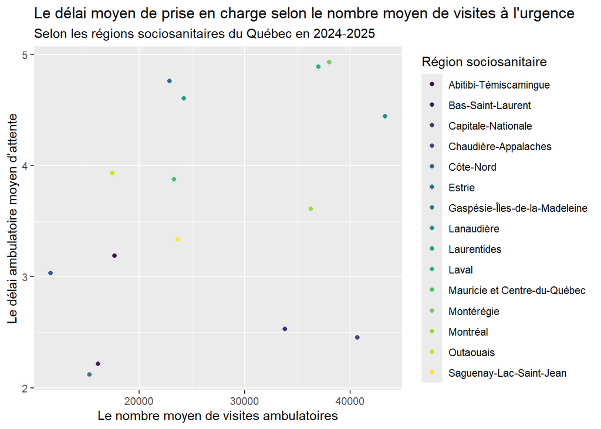

```r
# Relation entre le délai ambulatoire moyen et le le nombre moyen de visites ambulatoires
ggplot(filtered_urgences,
       aes(x = mean_visites_amb,
           y = mean_delai_pec_amb,
           colour = region)) +
  geom_point() +
  labs(title = "Le délai moyen de prise en charge selon le nombre moyen de visites à l'urgence",
       subtitle = "Selon les régions sociosanitaires du Québec en 2024-2025",
       x = "Le nombre moyen de visites ambulatoires",
       y = "Le délai ambulatoire moyen d'attente",
       colour = "Région sociosanitaire") +
  scale_color_viridis_d()
```

Comme nous pouvons le voir avec le nuage de point ci-dessus, le délai ambulatoire moyen ne varie pas en fonction du nombre moyen de visites ambulatoires selon les régions sociosanitaires. Personnellement, la relation linéaire entre ces deux variables semblait logique, mais comme nous pouvons le voir par la distribution des points, aucune relation proportionnelle ne peut être observée. Ainsi, comme pour la question de rechercher #3, le nombre moyen de visites ambulatoires ne peut pas expliquer, à lui seul, le délai ambulatoire moyen de prise en charge médical. Bref, les variables expliquant les délais d’attente de prise en charge semblent nombreuses.

Commençons par filtrer les données des urgences pour les 4 dernières années (filter(annee == c(“2020-2021”, “2021-2022”, “2022-2023”, “2023-2024”)). De plus, nous voulons avoir le nombre moyen de visites et le délai moyen pour les patients ambulatoires selon les régions sociosanitaires et selon les années. Le résultat du code est simple : nous obtenons seulement les données pour les 4 dernières années, en excluant le total provincial.

```r
# Filtrer les données des urgences pour le graphique des 4 dernières années cumulatives
filtered_urgences_cumul <- my_urgences %>%
  filter(annee == c("2020-2021", "2021-2022", "2022-2023", "2023-2024"),
         region != "Total provincial") %>%
  group_by(region, annee) %>%
  count(nb_visites_ambulatoire, delai_pec_ambulatoire) %>%
  summarise(mean_visites_amb = mean(nb_visites_ambulatoire),
            mean_delai_pec_amb = mean(delai_pec_ambulatoire)) %>%
  print()
```

```
## # A tibble: 58 × 4
## # Groups:   region [15]
##    region                annee     mean_visites_amb mean_delai_pec_amb
##    <chr>                 <chr>                <dbl>              <dbl>
##  1 Abitibi-Témiscamingue 2020-2021            7124.               2.00
##  2 Abitibi-Témiscamingue 2021-2022           32644                2.21
##  3 Abitibi-Témiscamingue 2022-2023            8466.               2.83
##  4 Abitibi-Témiscamingue 2023-2024           10529                2.00
##  5 Bas-Saint-Laurent     2020-2021           19557.               1.74
##  6 Bas-Saint-Laurent     2021-2022           24198.               1.36
##  7 Bas-Saint-Laurent     2022-2023            9308.               2.78
##  8 Bas-Saint-Laurent     2023-2024           25185.               1.62
##  9 Capitale-Nationale    2020-2021            7006                1.66
## 10 Capitale-Nationale    2021-2022           14730.               2.34
## # ℹ 48 more rows
```

Avec les données filtrées précédemment faites, nous pouvons maintenant construire un graphique qui permettra de regarder la tendance des 4 dernières années. Il est vrai que ces deux variables ne sont pas proportionnelles, soit que le nombre de visites n’explique pas le délai d’attente, mais regardons si les points des 4 dernières années se situent dans les mêmes valeurs.

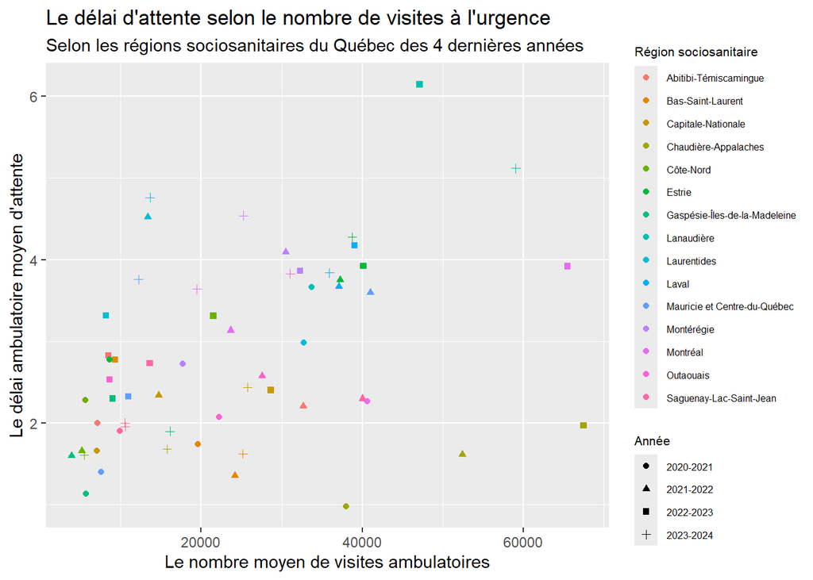

```r
# Relation entre le délai ambulatoire moyen et le le nombre moyen de visites ambulatoires pour les 4 dernières années
ggplot(filtered_urgences_cumul,
       aes(x = mean_visites_amb,
           y = mean_delai_pec_amb,
           colour = region,
           shape = annee)) +
  geom_jitter() +
  labs(title = "Le délai d'attente selon le nombre de visites à l'urgence",
       subtitle = "Selon les régions sociosanitaires du Québec des 4 dernières années",
       x = "Le nombre moyen de visites ambulatoires",
       y = "Le délai ambulatoire moyen d'attente",
       colour = "Région sociosanitaire",
       shape = "Année") +
  theme(legend.text = element_text(size = 6),
        legend.title = element_text(size = 8),
        legend.key.size = unit(0.5, "cm"),
        legend.spacing.y = unit(0.2, "cm"),
        legend.spacing.x = unit(0.2, "cm"),
        legend.margin = margin(5,5,5,5))
```

# 5 - Quelle est la corrélation entre la densité de la population et l’achalandage à l’urgence selon les régions sociosanitaires pour l’année courante?

De manière complémentaire, voici une première analyse, soit la proportion de la population en 2023 des régions sociosanitaires. Pour ce faire, nous pouvons (1) calculer le pourcentage de la proportion d’une région et (2) un diagramme circulaire pour les différentes régions. Tout d’abord, nous allons calculer le pourcentage de la population des différentes régions sociosanitaires. Ceci permettra de voir la distribution des habitants du Québec.

```r
# Pourcentage de la population selon les régions sociosanitaires
population_2023_pourcentage <- population_2023 %>%
  mutate(pourcentage = `population `/sum(`population `)*100) %>%
  arrange(desc(pourcentage)) %>%
  print()
```

```
## # A tibble: 15 × 4
##    region_sociosanitaire           `population ` rss   pourcentage
##    <chr>                                   <dbl> <chr>       <dbl>
##  1 "Montreal "                           2124865 06          24.1
##  2 "Monteregie"                          1494119 16          16.9
##  3 "Capitale-Nationale "                  795917 03           9.02
##  4 "Laurentides"                          664510 15           7.53
##  5 "Lanaudiere "                          551709 14           6.25
##  6 "Mauricie et Centre-du-Quebec"         543222 04           6.15
##  7 "Estrie"                               516919 05           5.86
##  8 "Laval "                               451986 13           5.12
##  9 "Chaudiere-Appalaches"                 448665 12           5.08
## 10 "Outaouais"                            418999 07           4.75
## 11 "Saguenay-Lac-Saint-Jean"              283234 02           3.21
## 12 "Bas-Saint-Laurent "                   202955 01           2.30
## 13 "Abitibi-Temiscamingue"                148797 08           1.69
## 14 "Gaspesie-Iles-de-la-Madeleine"         92104 11           1.04
## 15 "Cote-Nord"                             89979 09           1.02
```

Il est rapidement possible de voir que les régions de Montréal et de la Montérégie ont la densité de population la plus élevée, avec un pourcentage de 24.1% et 16.9%, respectivement. Ceci permet de rapidement mettre en évidence les régions sociosanitaires les plus peuplées ainsi que les moins peuplées.

Cependant, les pourcentages peuvent être redondants et difficiles à comparer lorsque les régions sont nombreuses. Ainsi, nous pouvons représenter la population des régions avec un diagramme circulaire. Toujours dans le but de faciliter l’interprétation, nous n’inclurons pas les pourcentages de la population. Cette représentation visuelle permettra simplement d’identifier les régions ayant le plus d’habitants ou le moins d’habitants.

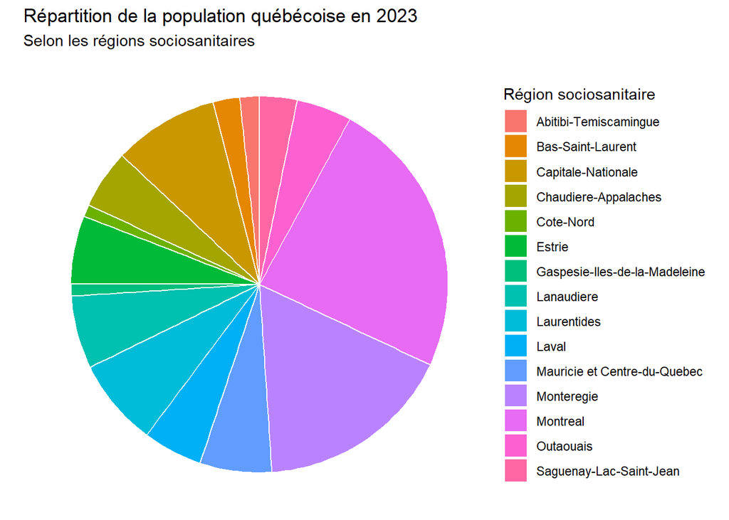

```r
# Diagramme circulaire de la population selon les régions du Québec
ggplot(population_2023_pourcentage, aes(x = "", y = `population `, fill = region_sociosanitaire)) +
  geom_bar(stat = "identity", width = 1, color = "white") +
  coord_polar("y") +
  labs(title = "Répartition de la population québécoise en 2023",
       subtitle = "Selon les régions sociosanitaires",
       fill = "Région sociosanitaire") +
  theme_void()
```

Ce graphique ne permet pas d’établir de lien direct avec les urgences du Québec, mais il permet de bien représenter la distribution de la population selon les régions sociosanitaires. Bref, il permet d’obtenir une vue d’ensemble de la population québécoise, ce qui sera pratique lorsque nous comparerons les données des urgences à la population.

Afin de clarifier un paramètre, l’achalandage d’une urgence correspond au nombre de visites pour les patients (nb_visites_total). Ceci étant dit, la première étape afin de répondre à cette question est de sélectionner les données que nous voulons dans le jeu de données my_urgences. Ainsi, nous voulons la région, le nombre de visites totales, l’année et le rss (variable nécessaire pour la jonction des données). Nous voulons filtrer les données pour l’année courante, en excluant le total provincial. De plus, nous allons regrouper les données selon la région et le rss. Finalement, nous allons faire la moyenne des visites totales afin de simplifier l’analyse.

```r
# Sélection des données des urgences en 2024-2025
urgences_5 <- my_urgences %>%
  select(region, nb_visites_total, annee, rss) %>%
  filter(annee == "2024-2025",
         region != "Total provincial") %>%
  group_by(region, rss) %>%
  summarise(mean_visites_total = mean(nb_visites_total)) %>%
  print()
```

```
## # A tibble: 15 × 3
## # Groups:   region [15]
##    region                        rss   mean_visites_total
##    <chr>                         <chr>              <dbl>
##  1 Abitibi-Témiscamingue         08                28576.
##  2 Bas-Saint-Laurent             01                28201.
##  3 Capitale-Nationale            03                48419.
##  4 Chaudière-Appalaches          12                66987
##  5 Côte-Nord                     09                19836
##  6 Estrie                        05                46781.
##  7 Gaspésie-Îles-de-la-Madeleine 11                18262.
##  8 Lanaudière                    14                73798.
##  9 Laurentides                   15                48802.
## 10 Laval                         13                58946
## 11 Mauricie et Centre-du-Québec  04                48390.
## 12 Montréal                      06                56058.
## 13 Montérégie                    16                60660.
## 14 Outaouais                     07                31985.
## 15 Saguenay-Lac-Saint-Jean       02                44897.
```

Ensuite, nous devons ajouter les données de la population (population_2023) selon les régions sociosanitaires au nouveau jeu de données (urgences_5). Pour ce faire, nous allons joindre les deux jeux de données avec la fonction inner_join() et la variable commune choisie est le rss (numéro de région sociosanitaire). Le résultat de cette fonction sera d’obtenir un jeu de données (urgences_5_pop) qui contient la région, le nombre moyen de visites totales ainsi que la population en 2023 pour les régions sociosanitaires.

```r
# Joindre les données de la population avec celles des urgences
urgences_5_pop <- inner_join(urgences_5, population_2023, by = "rss") %>%
  print()
```

```
## # A tibble: 15 × 5
## # Groups:   region [15]
##    region           rss   mean_visites_total region_sociosanitaire `population `
##    <chr>            <chr>              <dbl> <chr>                         <dbl>
##  1 Abitibi-Témisca… 08                28576. "Abitibi-Temiscaming…        148797
##  2 Bas-Saint-Laure… 01                28201. "Bas-Saint-Laurent "         202955
##  3 Capitale-Nation… 03                48419. "Capitale-Nationale "        795917
##  4 Chaudière-Appal… 12                66987  "Chaudiere-Appalache…        448665
##  5 Côte-Nord        09                19836  "Cote-Nord"                   89979
##  6 Estrie           05                46781. "Estrie"                     516919
##  7 Gaspésie-Îles-d… 11                18262. "Gaspesie-Iles-de-la…         92104
##  8 Lanaudière       14                73798. "Lanaudiere "                551709
##  9 Laurentides      15                48802. "Laurentides"                664510
## 10 Laval            13                58946  "Laval "                     451986
## 11 Mauricie et Cen… 04                48390. "Mauricie et Centre-…        543222
## 12 Montréal         06                56058. "Montreal "                 2124865
## 13 Montérégie       16                60660. "Monteregie"                1494119
## 14 Outaouais        07                31985. "Outaouais"                  418999
## 15 Saguenay-Lac-Sa… 02                44897. "Saguenay-Lac-Saint-…        283234
```

Nous pouvons maintenant construire le graphique avec le nouveau jeu de données, soit urgences_5_pop. Ici, afin de voir s’il y a une relation linéaire entre les deux variables, nous allons utiliser ggplot et geom_point, où la population est la variable “x” et le nombre moyen de visites est la variable “y”. Nous regardons également la relation selon les régions sociosanitaires.

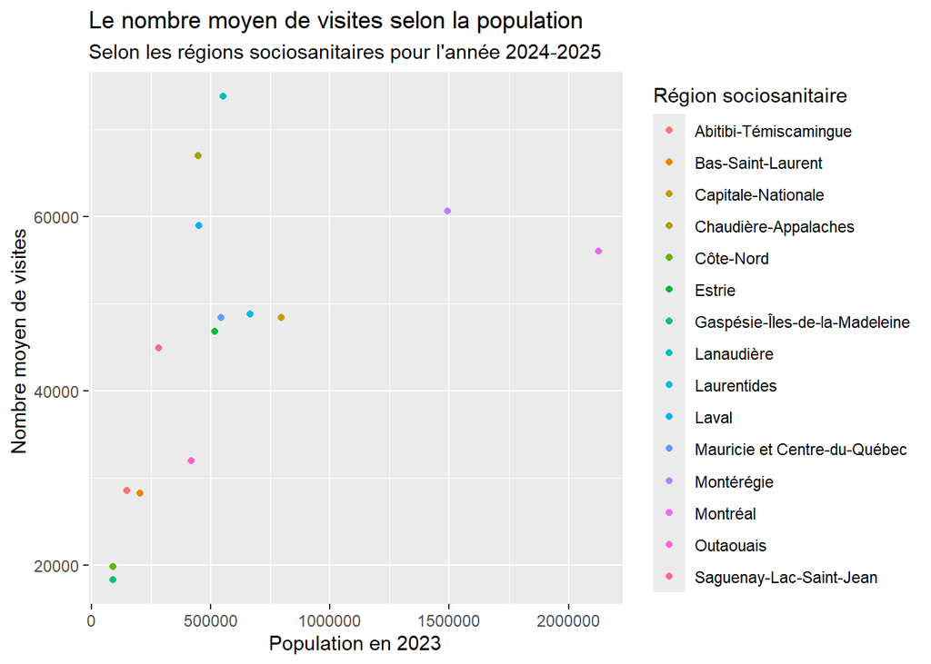

```r
# Visualisation de la relation entre le nombre de visites selon la population en 2024-2025
ggplot(urgences_5_pop,
       aes(x = `population `,
           y = mean_visites_total,
           colour = region)) +
  geom_point() +
  labs(title = "Le nombre moyen de visites selon la population",
       subtitle = "Selon les régions sociosanitaires pour l'année 2024-2025",
       x = "Population en 2023",
       y = "Nombre moyen de visites ",
       colour = "Région sociosanitaire")
```

Tout d’abord, nous ne pouvons pas voir de relation linéaire entre les deux variables. Cependant, nous sommes en mesure de faire quelques conclusions. En effet, nous pouvons voir une densité de points plus intense entre un intervalle de population de 100 000 à 750 000 habitantes et un intervalle de visites de 20 000 à 50 000. Cette observation permet de supposer que, pour cette année, la majorité des régions ont un nombre moyen de visites assez semblable. Ensuite, nous sommes en mesure de remarquer deux points particuliers : les régions de la Gaspésire-Îles-de-la-Madeleine (vert bleu) et Côte-Nord (vert jaune). En effet, ces deux points ont la population la plus petite ainsi que le nombre de visites le plus petit. Ceci mène à penser que plus la population est petite, moins il y a de visites aux urgences. Toutefois, ce n’est pas le cas. La région de Lanaudière (bleu vert) se démarque : pour une population d’environ 500 000, le nombre de visites est le plus élevé (supérieur à 70 000 visites). De plus, la région de Montréal (mauve) vient également briser cette supposition puisque pour la population la plus grande (supérieure à 2 000 000), le nombre de visites est inférieur à 60 000. Ainsi, il n’est pas possible d’établir une relation linéaire entre les deux variables. Évidemment, il y a plusieurs facteurs qui peuvent expliquer cette problématique, telle qu’une population plus vieillissante (région de Lanaudière). Nous avons toutefois été en mesure d’établir une tendance en ce qui concerne la majorité des régions pour le nombre de visites et la population pour l’année courante.

Afin de confirmer qu’il n’existe pas de relation linéaire entre la population et le nombre de visites pour les régions sociosanitaires, nous pouvons établir le coefficient de corrélation. Pour ce faire, nous allons utiliser la fonction lm() afin d’obtenir le coefficient.

```r
# Coefficient de corrélation entre la population et le nombre de visites en 2024-2025
lm(mean_visites_total ~ `population `, data = urgences_5_pop) %>%
  summary() %>%
  print()
```

```
##
## Call:
## lm(formula = mean_visites_total ~ `population `, data = urgences_5_pop)
##
## Residuals:
##    Min     1Q Median     3Q    Max
## -19187 -10850    831   4069  29012
##
## Coefficients:
##                Estimate Std. Error t value Pr(>|t|)
## (Intercept)   3.598e+04  5.758e+03   6.248 2.98e-05 ***
## `population ` 1.596e-02  7.263e-03   2.198   0.0467 *
## ---
## Signif. codes:  0 '***' 0.001 '**' 0.01 '*' 0.05 '.' 0.1 ' ' 1
##
## Residual standard error: 14950 on 13 degrees of freedom
## Multiple R-squared:  0.2709, Adjusted R-squared:  0.2149
## F-statistic: 4.831 on 1 and 13 DF,  p-value: 0.04667
```

Ce résultat de coefficient de corrélation permet d’appuyer notre analyse du graphique précédent (question 5). En effet, le coefficient de corrélation est de 0.2709, ce qui s’éloigne de la valeur de 1 (relation linéaire parfaite). Ainsi, nous sommes en mesure de conclure que la population ne peut pas expliquer, à elle seule, le nombre moyen de visites aux urgences des régions du Québec. Le graphique a permis de bien visualiser la distinction entre les différentes régions, rappelons l’exemple de Montréal. Malgré une population très élevée, le nombre moyen de visites est en bas de 60 000 pour l’année courante, ce qui tend vers la majorité des régions.

# 6 - Quelle est la relation entre l’achalandage, la densité de la population et le nombre de patients pris en charge dans les urgences selon les régions sociosanitaires du Québec pour l’année courante?

Afin de clarifier un paramètre, l’achalandage d’une urgence correspond au nombre de visites pour les patients (nb_visites_total). Afin de répondre à la question ci-dessus, nous devons sélectionner le nombre de visites totales, le rss (joindre les données), la région, l’année et le nombre d’usagers pris en charge pour l’année courante. Nous voulons également exclure le total provincial. Finalement, nous voulons les moyennes des variables selon les régions.

```r
# Sélection des données dans my_urgences pour le graphique suivant
urgences_Q6 <- my_urgences %>%
  select(nb_visites_total, rss, region, nb_usagers_pec_total, annee) %>%
  filter(annee == "2024-2025",
         region != "Total provincial") %>%
  group_by(region, rss) %>%
  summarise(mean_visites = mean(nb_visites_total),
            mean_usagers_pec = mean(nb_usagers_pec_total)) %>%
  print()
```

```
## # A tibble: 15 × 4
## # Groups:   region [15]
##    region                        rss   mean_visites mean_usagers_pec
##    <chr>                         <chr>        <dbl>            <dbl>
##  1 Abitibi-Témiscamingue         08          28576.           23937.
##  2 Bas-Saint-Laurent             01          28201.           24357.
##  3 Capitale-Nationale            03          48419.           39706.
##  4 Chaudière-Appalaches          12          66987            57900
##  5 Côte-Nord                     09          19836            15867.
##  6 Estrie                        05          46781.           37904.
##  7 Gaspésie-Îles-de-la-Madeleine 11          18262.           15977.
##  8 Lanaudière                    14          73798.           54434.
##  9 Laurentides                   15          48802.           37327.
## 10 Laval                         13          58946            45276
## 11 Mauricie et Centre-du-Québec  04          48390.           37957.
## 12 Montréal                      06          56058.           45335.
## 13 Montérégie                    16          60660.           44164.
## 14 Outaouais                     07          31985.           23843.
## 15 Saguenay-Lac-Saint-Jean       02          44897.           38185.
```

Avec les données sélectionnées précédentes, nous pouvons joindre les données de la population en utilisant le rss comme variable commune. Le résultat de cette jonction est que la population de la région sociosanitaire est maintenant dans la même table de valeurs que les deux variables suivantes : le nombre de visites totales et le nombre de patients pris en charge.

```r
# Joindre les données de la population au jeu de données urgences_Q6
urgences_Q6_pop <- inner_join(urgences_Q6, population_2023, by = "rss") %>%
  print()
```

```
## # A tibble: 15 × 6
## # Groups:   region [15]
##    region              rss   mean_visites mean_usagers_pec region_sociosanitaire
##    <chr>               <chr>        <dbl>            <dbl> <chr>
##  1 Abitibi-Témiscamin… 08          28576.           23937. "Abitibi-Temiscaming…
##  2 Bas-Saint-Laurent   01          28201.           24357. "Bas-Saint-Laurent "
##  3 Capitale-Nationale  03          48419.           39706. "Capitale-Nationale "
##  4 Chaudière-Appalach… 12          66987            57900  "Chaudiere-Appalache…
##  5 Côte-Nord           09          19836            15867. "Cote-Nord"
##  6 Estrie              05          46781.           37904. "Estrie"
##  7 Gaspésie-Îles-de-l… 11          18262.           15977. "Gaspesie-Iles-de-la…
##  8 Lanaudière          14          73798.           54434. "Lanaudiere "
##  9 Laurentides         15          48802.           37327. "Laurentides"
## 10 Laval               13          58946            45276  "Laval "
## 11 Mauricie et Centre… 04          48390.           37957. "Mauricie et Centre-…
## 12 Montréal            06          56058.           45335. "Montreal "
## 13 Montérégie          16          60660.           44164. "Monteregie"
## 14 Outaouais           07          31985.           23843. "Outaouais"
## 15 Saguenay-Lac-Saint… 02          44897.           38185. "Saguenay-Lac-Saint-…
## # ℹ 1 more variable: `population ` <dbl>
```

Nous avons maintenant le jeu de données propres et contenant seulement les données dont nous avons besoin (urgences_Q6_pop). Nous sommes maintenant en mesure de représenter la relation entre le nombre de visites totales moyennes et le nombre moyen de patients pris en charge, selon la population des régions sociosanitaires. Pour ce faire, nous utiliserons les facettes afin de bien isoler les régions sociosanitaires, pour l’année 2024-2025. Finalement, afin de bien distinguer les couleurs du gradient de la population, nous utiliserons le theme_dark() afin d’obtenir un fond foncé.

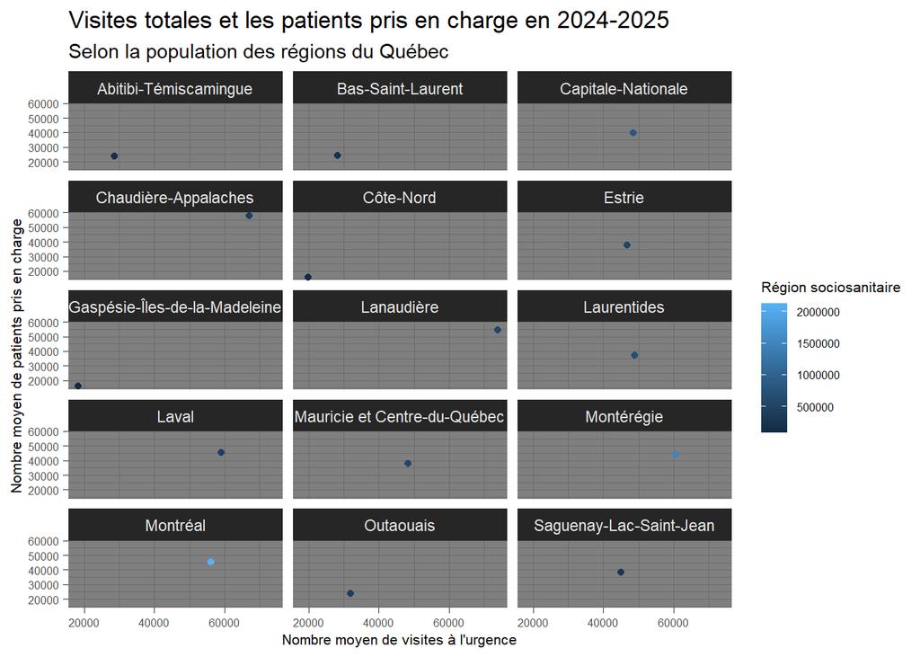

```r
# Visualisation des visites totales, des patients pris en charge et de la population pour les régions en 2024-2025
ggplot(urgences_Q6_pop,
       aes(x = mean_visites,
           y = mean_usagers_pec,
           colour = `population `)) +
  geom_point() +
  facet_wrap(~ region, nrow = 5) +
  labs(title = "Visites totales et les patients pris en charge en 2024-2025",
       subtitle = "Selon la population des régions du Québec",
       x = "Nombre moyen de visites à l'urgence",
       y = "Nombre moyen de patients pris en charge",
       color = "Région sociosanitaire") +
  theme_dark() +
  theme(legend.text = element_text(size = 6),
        legend.title = element_text(size = 8),
        legend.key.size = unit(0.5, "cm"),
        legend.margin = margin(5,5,5,5),
        axis.title.x = element_text(size = 8),
        axis.title.y = element_text(size = 8),
        axis.text = element_text(size = 6))
```

Cette présente analyse se terminera par la détermination du pourcentage de visites de patients âgés de 75 ans et plus par rapport au nombre total de visites. Cette proportion permettra de vérifier notre hypothèse, soit que certaines régions ont une population plus vieillissante, ce qui fait augmenter le nombre de visites totales à l’urgence, malgré une faible population. Pour ce faire, nous utiliserons les données pour l’année courante en excluant le total provincial.

```r
# Pourcentage de patients âgés de 75 ans et plus en 2024-2025
Pourcentage_75_ans <- my_urgences %>%
  select(region, annee, nb_usagers_75ans_et_plus_total, nb_visites_total) %>%
  filter(annee == "2024-2025",
         region != "Total provincial") %>%
  group_by(region) %>%
  summarise(mean_75_ans = mean(nb_usagers_75ans_et_plus_total),
            mean_visites = mean(nb_visites_total)) %>%
  mutate(pourcentage = mean_75_ans/mean_visites*100) %>%
  arrange(desc(pourcentage)) %>%
  print()
```

```
## # A tibble: 15 × 4
##    region                        mean_75_ans mean_visites pourcentage
##    <chr>                               <dbl>        <dbl>       <dbl>
##  1 Laval                              11323        58946         19.2
##  2 Montérégie                         11490.       60660.        18.9
##  3 Lanaudière                         13455        73798.        18.2
##  4 Mauricie et Centre-du-Québec        8669.       48390.        17.9
##  5 Laurentides                         8718        48802.        17.9
##  6 Bas-Saint-Laurent                   4833        28201.        17.1
##  7 Capitale-Nationale                  8280.       48419.        17.1
##  8 Gaspésie-Îles-de-la-Madeleine       3070.       18262.        16.8
##  9 Estrie                              7700.       46781.        16.5
## 10 Chaudière-Appalaches               10980.       66987         16.4
## 11 Saguenay-Lac-Saint-Jean             7236        44897.        16.1
## 12 Montréal                            8200.       56058.        14.6
## 13 Outaouais                           4505.       31985.        14.1
## 14 Abitibi-Témiscamingue               3490.       28576.        12.2
## 15 Côte-Nord                           2400        19836         12.1
```

### Discussion générale et conclusion

Dans la présente section, nous résumerons les différentes discussions et analyses faites dans la section analyse. Tout d’abord, la relation qui explique les délais d’attente aux urgences ainsi que le nombre de visites totales est loin d’être simple. Cette analyse a permis de démontrer qu’il n’y a pas de lien proportionnel (relation linéaire) entre les variables testées. Ces résultats ont permis d’émettre l’hypothèse que la relation expliquant les délais d’attente et le nombre de visites implique plusieurs facteurs, tels que des facteurs intrinsèques (patients à l’urgence) et facteurs extrinsèques (conditions météo qui empêchent l’arrivée du personnel). Ainsi, il est très difficile d’établir un lien de cause à effet, avec seulement quelques variables, pour ce type de relation.

Ensuite, il semblait logique de supposer qu’une forte population entraîne un nombre de visites plus grand aux urgences. Cependant, nous avons remarqué que ce n’est pas le cas : une forte population n’explique pas le nombre de patients à l’urgence. Ceci nous a mené à penser qu’une population vieillissante pourrait expliquer une hausse de visites aux urgences. Toutefois, nous n’avons pas pu établir un lien pour cette variable. En effet, la proportion de patients âgés, selon les différentes régions, est assez semblable. Ces résultats ont donc permis de comprendre qu’il est difficile de prédire l’achalandage d’une urgence, en fonction de la densité de population, mais également en fonction de la tranche d’âge de ladite population.

Pour poursuivre, il est important de mentionner que ces données restent approximatives. De plus, ces observations sont également des moyennes des urgences : certains cas isolés sont perdus. En effet, nous devons considérer ce biais lors de l’interprétation des résultats. De manière générale, les urgences du Québec ont des délais d’attente allant de 2 à 4 heures, ce qui est acceptable. Cependant, ce type de données ne permet pas d’identifier des cas isolés, tels qu’une journée de tempête ou de grève syndicale. L’analyse nous permet toutefois d’établir des observations générales : les lacunes isolées dans les urgences doivent être identifiées de manière individuelle. Un autre biais est qu’il est difficile de prédire les données des urgences, telles que le nombre de visites, les patients sur civière ou encore la durée du séjour. En effet, aucun moyen connu ne permet de prédire un accident ou encore, une pandémie. Nous pouvons effectuer une analyse sur l’année courante et les dernières années, mais il est impossible de prédire, avec précision, les statistiques pour la prochaine année. Finalement, le taux de migration d’une région à une autre est également difficile à prédire, ce qui introduit également un biais quant à la relation des urgences avec la population.

Afin d’émettre une conclusion générale pour cette analyse, tous les résultats présentés laissent supposer que la gestion des centres hospitaliers des différentes régions sociosanitaires fait partie de la relation entre les délais d’attente de prise en charge des urgences. Il n’existe pas une variable, à elle seule, qui peut expliquer ces délais d’attente : une multitude de facteurs doivent être pris en compte. En effet, une bonne gestion des urgences, soit avoir un personnel proportionnel à la demande, avoir assez de lits disponibles ou encore, avoir assez d’équipements médicaux, peut grandement améliorer la situation d’une urgence. Ainsi, il est le devoir des gouvernements (ex. Ministère de la Santé) de discuter avec les membres du personnel hospitalier afin d’identifier les lacunes, au sein des urgences d’une région, ainsi que d’essayer de réduire les problématiques rencontrées dans ces urgences.